# KD Practicum 5.1

## Data budgeting and exploration

### The Ames housing data

In the following exercise we’ll use the Ames housing data set[^1] containing information on 2,930 properties in Ames, Iowa, including columns related to: house characteristics (bedrooms, garage, fireplace, pool, porch, etc.), location (neighborhood), lot information (zoning, shape, size, etc.), ratings of condition and quality and sale price.

We will specifically use a processed version of the data where several of the variables are formatted as ordered factors.

### Modelling aims

Our modeling goal is to predict the sale **price** of a house based on other information we have, such as its characteristics and location.

We expect to have a big difference in house prices among neighborhood. It is known that the top expensive neighborhoods are **North Ridge Heights, North Risge and Stone Brook** with median house prices of approximately $300,000, three times as high as the median of the 3 cheapest neighborhoods, which are **Briar Dale, Iowa DOT Rail Road and Meadow Village**. As most of us are unfamiliar with boroughs in Ames, let’s look where these neighborhoods are.

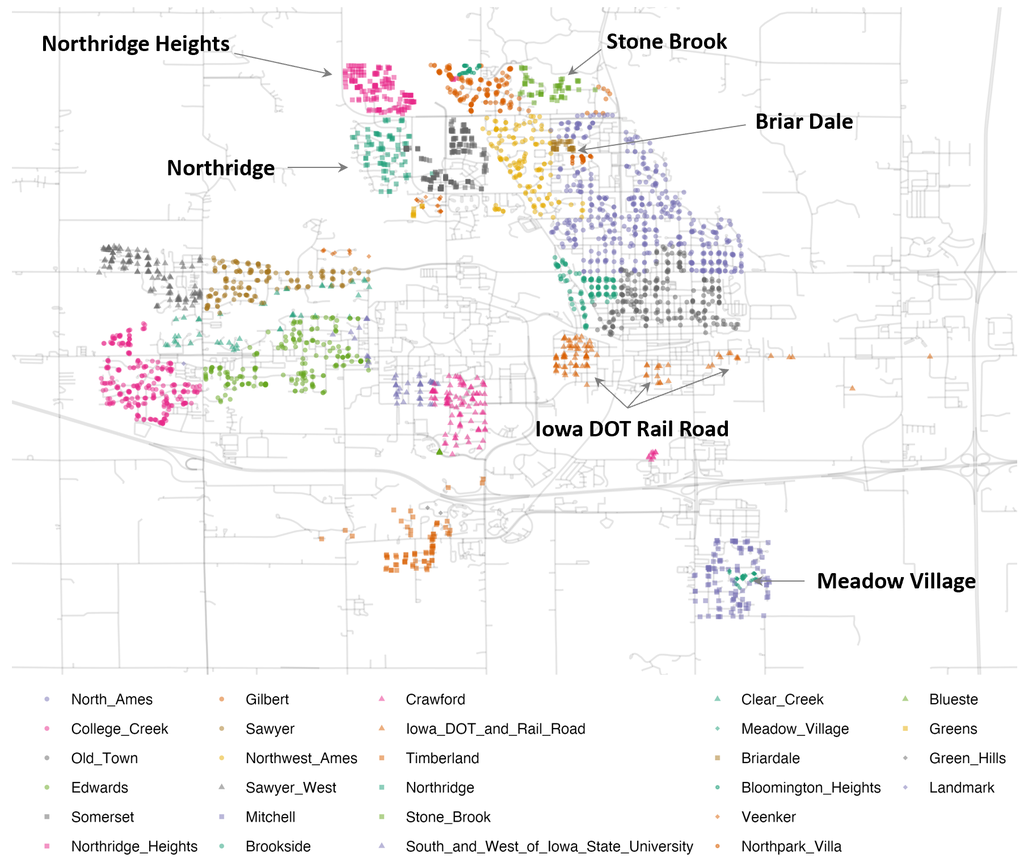

### Modelling overview

As in the previous exercise, the steps you need to go through are similar. They require you to

- understand your data so as to make good data budgeting choice,
- know how to provide the modeling function with the right formula,
- capture and extract information from the object that the modeling function generates,
- aggregate and interpret the extracted model coefficients,
- and validate your findings with the testing dataset.

### Data loading with data()

Ames housing data are accessible after **tidymodels** are loaded into R. To work with the data directly, we use the `data()` function from the utils package.

**`data()`** was originally intended to allow users to load data sets from packages for use in their examples, and as such it loaded the data sets into the work space **`.GlobalEnv`**. This avoided having large datasets in memory when not in use: that need has been almost entirely superseded by lazy-loading of datasets.

```r
library(tidyverse)
library(tidymodels)
library(magrittr)

tidymodels_prefer() # resolve package conflicts using tidy models methods
data(ames)
```

### Data transformation

When modeling house prices in Ames, a strong argument can be made that the price should be **log-transformed**.

```r
ames %<>% mutate(Sale_Price = log10(Sale_Price))
# Note that %<>% is equivalent to ames <- ames %>% mutate(...)
```

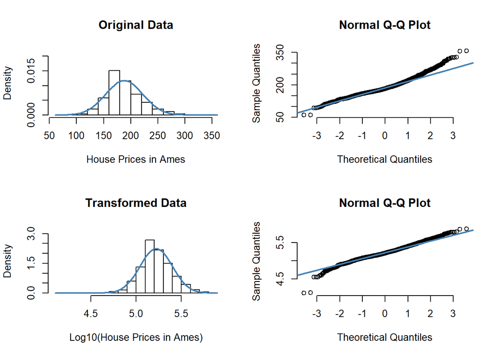

```r
par(mfrow = c(2,2)) # Initiate grid for plotting with 2 x 2 panes.

# Pane 1: Plot histogram of House sale prices
x <- exp(ames$Sale_Price)# Get data vector for plotting
x2 <- seq(min(x), max(x), length = 40) # Split data into bins

# Calculate PDF shape from plotted data
fun <- dnorm(x2, mean = mean(x), sd = sd(x))

# Plot histogram
hist(x, prob = TRUE, col = "white",
     ylim = c(0, max(fun)+0.01),
     xlab = "House Prices in Ames",
     main = "Original Data")
# Plot PDF
lines(x2, fun, col = "steelblue", lwd = 2)

# Pane 2: Plot Q-Q plot of House sale prices
qqnorm(x, pch = 1, frame = FALSE)
qqline(x, col = "steelblue", lwd = 2)

# Pane 3: Plot histogram of House sale prices, log-ed this time.
x <- ames$Sale_Price
x2 <- seq(min(x), max(x), length = 40) #
fun <- dnorm(x2, mean = mean(x), sd = sd(x))

hist(x, prob = TRUE, col = "white",
     ylim = c(0, max(fun)+1),
     xlab = "Log10(House Prices in Ames)",
     main = "Transformed Data")
lines(x2, fun, col = "steelblue", lwd = 2)

# Pane 4: Plot Q-Q plot of House sale prices, log-ed this time.
qqnorm(x, pch = 1, frame = FALSE)
qqline(x, col = "steelblue", lwd = 2)
```

The advantages of this type of transformation are that no houses would be predicted with negative sale prices and that errors in predicting expensive houses will not have an undue influence on the model. Also, from a statistical perspective, a logarithmic transform may also stabilize the variance in a way that makes inference more legitimate.

### Data splitting by random sampling

The primary approach for empirical model validation is to split the existing pool of data into two distinct sets, the training set and the test set. One portion of the data is used to develop and optimize the model. This *training set* is usually the majority of the data. These data are a sandbox for model building where different models can be fit, feature engineering strategies are investigated, and so on.

The other portion of the data is placed into the *test set*. This is held in reserve until one or two models are chosen as the methods most likely to succeed. The test set is then used as the final arbiter to determine the efficacy of the model. It is critical to look at the test set only once; otherwise, it becomes part of the modeling process.

Suppose we allocate 80% of the data to the training set and the remaining 20% for testing. The most common method is to use simple random sampling (which you have became familiar with in KD Practicum 2.2). The **rsample** package has tools for making data splits such as this; the function `initial_split()` was created for this purpose. It takes the data frame as an argument as well as the proportion to be placed into training.

```r
set.seed(501)
ames_split <- initial_split(ames, prop = 0.80)
```

The printed information denotes the amount of data in the training set (n=2,344), the amount in the test set (n=586), and the size of the original pool of samples (n=2,930).

Although the resulting partitioning object is not direclty usable for modelling, it can be quite interesting to inspect its class, type and internal structure.

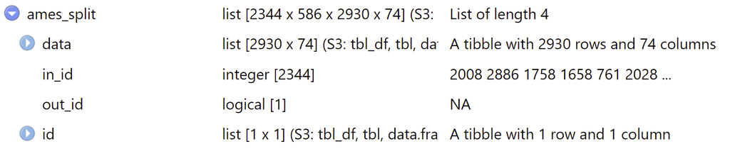

```r
class(ames_split) ; typeof(ames_split) ; ames_split ; summary(ames_split)
```

```
## [1] "initial_split" "mc_split"      "rsplit"
```

```
## [1] "list"
```

```
## <Training/Testing/Total>
## <2344/586/2930>
```

```
##        Length Class  Mode
## data     74   tbl_df list
## in_id  2344   -none- numeric
## out_id    1   -none- logical
## id        1   tbl_df list
```

The object `ames_split` is an `rsplit` object and contains only the partitioning information. To get the resulting data sets, we apply two more functions:

```r
ames_train <- training(ames_split)
ames_test  <-  testing(ames_split)
```

These objects are data frames with the same columns as the original data but only the appropriate rows for each set.

### Stratified sampling

Simple random sampling is appropriate in many cases but there are exceptions. When there is a dramatic *class imbalance* in classification problems, one class occurs much less frequently than another. Using a simple random sample may haphazardly allocate these infrequent samples disproportionately into the training or test set.

To avoid this, **stratified sampling** can be used. The training/test split is conducted separately within each class and then these subsamples are combined into the overall training and test set.

Although **this is not entirely the case for sale prices in our data set**, the sale price distribution is right-skewed, with proportionally slightly more inexpensive houses than expensive houses on either side of the center of the distribution.

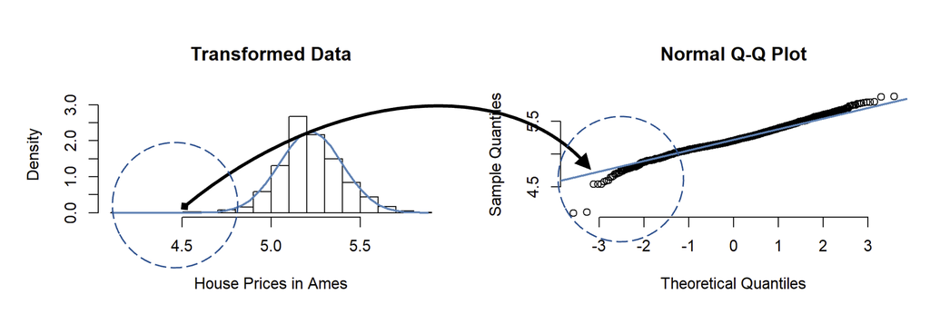

If there were simply more bias in the data, the worry here with simple splitting is that the more expensive houses would not be well represented in the training set; this would increase the risk that our model would be ineffective at predicting the price for such properties.

```r
set.seed(502)
ames_split <- initial_split(ames, prop = 0.80, strata = Sale_Price)
ames_train <- training(ames_split)
ames_test  <-  testing(ames_split)
```

## Fitting models with parsnip

The **parsnip** package, one of the R packages that are part of the **tidymodels** metapackage, provides a fluent and standardized interface for a variety of different models. Specifically, we will focus on how to `fit()` and `predict()` directly with a **parsnip** object, which may be a good fit for some straightforward modeling problems.

### Modelling basics

Suppose that **a linear regression model** was our initial choice. This is equivalent to specifying that the outcome data is numeric and that the predictors are related to the outcome in terms of simple slopes and intercepts:

$$y_i = \beta_0 + \beta_1x_1 + ...+
\beta_px_{pi}$$

A variety of methods can be used to estimate the model parameters:

- *Ordinary linear regression* uses the traditional method of least squares to solve for the model parameters. The syntax for linear regression using the function `stats::lm()` is: **`model <- lm(formula, data, …)`** where `...` symbolizes other options to pass to `lm()`. The function does *not* have an `x`/`y` interface, where we might pass in our outcome as `y` and our predictors as `x`.
- *Regularized linear regression* adds a penalty to the least squares method to encourage simplicity by removing predictors and/or shrinking their coefficients towards zero. This can be executed using Bayesian or non-Bayesian techniques.
  - To estimate with regularization, a Bayesian model can be fit using the **rstanarm** package: **`model <- stan_glm(formula, data, family = "gaussian", …)`** . In this case, the other options passed via `...` would include arguments for the prior distributions of the parameters as well as specifics about the numerical aspects of the model. As with `lm()`, only the formula interface is available.
  - A popular non-Bayesian approach to regularized regression is the **glmnet** model[^2]. Its syntax is: **`model <- glmnet(x = matrix, y = vector, family = "gaussian", …)`**. In this case, the predictor data must already be formatted into a numeric matrix; there is only an `x`/`y` method and no formula method.

Note that these interfaces are heterogeneous in either how the data are passed to the model function or in terms of their arguments.

### Modelling interface of parsnip

For tidymodels, the approach to specifying a model is intended to be more unified:

- *Specify the type of model based on its mathematical structure* (e.g., linear regression, random forest, KNN, etc).
- *Specify the engine for fitting the model.* Most often this reflects the software package that should be used, like Stan or **glmnet**. These are models in their own right, and **parsnip** provides consistent interfaces by using these as engines for modeling.
- *When required, declare the mode of the model.* The mode reflects the type of prediction outcome. For numeric outcomes, the mode is regression; for qualitative outcomes, it is classification.<sup>13</sup> If a model algorithm can only address one type of prediction outcome, such as linear regression, the mode is already set.

These specifications are built without referencing the data. For example, the ordinary linear regression interface can look like this:

```
linear_reg() %>% set_engine("lm")
```

whilst the regularization interfaces are as follows:

```
linear_reg() %>% set_engine("glmnet")

linear_reg() %>% set_engine("stan")
```

Once the details of the model have been specified, the model estimation can be done with either the `fit()` function (to use a formula) or the `fit_xy()` function (when your data are already pre-processed). The **parsnip** package allows the user to be indifferent to the interface of the underlying model; you can always use a formula even if the modeling package’s function only has the `x`/`y` interface.

The `translate()` function can provide details on how **parsnip** converts the user’s code to the package’s syntax. For ordinary linear regression, the code may look like:

```r
linear_reg() %>% set_engine("lm") %>% translate()
```

```
## Linear Regression Model Specification (regression)
##
## Computational engine: lm
##
## Model fit template:
## stats::lm(formula = missing_arg(), data = missing_arg(), weights = missing_arg())
```

Note that `missing_arg()` is just a placeholder for the data that has yet to be provided.

### Modelling housing prices

Let’s walk through how to predict the sale price of houses in the Ames data as a function of only longitude and latitude:

```r
lm_model <- linear_reg() %>% set_engine("lm")
lm_form_fit <- lm_model %>% fit(Sale_Price ~ Longitude + Latitude, data = ames_train)
lm_form_fit
```

```
## parsnip model object
##
##
## Call:
## stats::lm(formula = Sale_Price ~ Longitude + Latitude, data = data)
##
## Coefficients:
## (Intercept)    Longitude     Latitude
##    -302.974       -2.075        2.710
```

Alternatively, we can use the `x`/`y` interface. It will have no impact upon the modelling result, so feel free to use whichever way you like.

```r
lm_xy_fit <-
  lm_model %>%
  fit_xy(
    x = ames_train %>% select(Longitude, Latitude),
    y = ames_train %>% pull(Sale_Price)
  )
```

**parsnip** supports various engines for linear regression after prior installation of their packages. Let’s see what on menu:

```r
show_engines('linear_reg')
```

```
## # A tibble: 7 × 2
##   engine mode
##   <chr>  <chr>
## 1 lm     regression
## 2 glm    regression
## 3 glmnet regression
## 4 stan   regression
## 5 spark  regression
## 6 keras  regression
## 7 brulee regression
```

### Accessing information in model objects

Once the model is created and fit, we can use the results in a variety of ways; we might want to plot, print, or otherwise examine the model output. Several quantities are stored in a **parsnip** model object, including the fitted model. This can be found in an element called `fit`, which can be returned using the `extract_fit_engine()` function:

```r
lm_form_fit %>% extract_fit_engine()
```

```
##
## Call:
## stats::lm(formula = Sale_Price ~ Longitude + Latitude, data = data)
##
## Coefficients:
## (Intercept)    Longitude     Latitude
##    -302.974       -2.075        2.710
```

Normal methods can be applied to this object, such as `coef()`, `resid()`, etc.

### Tidying a model’s readout

You see that this information is not readily accessible for further analyses. It is nothing that cannot be overcome with some degree of formatting, but it is a hindrance. As a solution, the **broom** package can convert many types of model objects to a tidy structure. For example, using the `tidy()` method on the linear model produces:

```r
tidy(lm_form_fit)
```

```
## # A tibble: 3 × 5
##   term        estimate std.error statistic  p.value
##   <chr>          <dbl>     <dbl>     <dbl>    <dbl>
## 1 (Intercept)  -303.      14.4       -21.0 3.64e-90
## 2 Longitude      -2.07     0.129     -16.1 1.40e-55
## 3 Latitude        2.71     0.180      15.0 9.29e-49
```

```r
summary(lm_form_fit$fit)
```

```
##
## Call:
## stats::lm(formula = Sale_Price ~ Longitude + Latitude, data = data)
##
## Residuals:
##      Min       1Q   Median       3Q      Max
## -1.02861 -0.09798 -0.01345  0.09648  0.57925
##
## Coefficients:
##              Estimate Std. Error t value Pr(>|t|)
## (Intercept) -302.9736    14.3983  -21.04   <2e-16 ***
## Longitude     -2.0749     0.1286  -16.13   <2e-16 ***
## Latitude       2.7097     0.1804   15.02   <2e-16 ***
## ---
## Signif. codes:  0 '***' 0.001 '**' 0.01 '*' 0.05 '.' 0.1 ' ' 1
##
## Residual standard error: 0.1604 on 2339 degrees of freedom
## Multiple R-squared:  0.1684, Adjusted R-squared:  0.1677
## F-statistic: 236.8 on 2 and 2339 DF,  p-value: < 2.2e-16
```

### Predicting prices for new houses

Another area where **parsnip** diverges from conventional R modeling functions is the format of values returned from `predict()`. For predictions, **parsnip** always conforms to the following rules:

1. The results are always a tibble.
2. The column names of the tibble are always predictable.
3. There are always as many rows in the tibble as there are in the input data set.

For example, when numeric data are predicted:

```r
ames_test_small <- ames_test %>% slice(1:5)
predict(lm_form_fit, new_data = ames_test_small)
```

```
## # A tibble: 5 × 1
##   .pred
##   <dbl>
## 1  5.22
## 2  5.21
## 3  5.28
## 4  5.27
## 5  5.28
```

### Exercises

This exercise closes the theme of regression modelling by introducing parsnip pipelines, data budgeting and stratified sampling. Your goal is to use the Ames housing dataset to **predict sale price** of a house **from the total living area** and **the condition** that the property is at.

1. Load `Practicum.5.1.csv`. Check the format of the data. Does the format follows the principles of tidy dataset, or are further data transformation needed? Are these data ready for modelling? If not transform the data accordingly your needs.

   ```r
   data <- read_csv(file = "~/OneDrive/Documents/Knowledge Discovery/Practicals/Data/Practicum.5.1.csv")
   data %<>% pivot_wider(values_from = "Value_SF", names_from = "Area_SF")
   data %>% print(n=3)
   ```

   ```
   ## # A tibble: 2,930 × 9
   ##      ID Sale_Price Overall_Cond  Bsmt_…¹ Total…² First…³ Secon…⁴ Wood_…⁵ Open_…⁶
   ##   <dbl>      <dbl> <chr>           <dbl>   <dbl>   <dbl>   <dbl>   <dbl>   <dbl>
   ## 1     1     215000 Average           441    1080    1656       0     210      62
   ## 2     2     105000 Above_Average     270     882     896       0     140       0
   ## 3     3     172000 Above_Average     406    1329    1329       0     393      36
   ## # … with 2,927 more rows, and abbreviated variable names ¹Bsmt_Unf_SF,
   ## #   ²Total_Bsmt_SF, ³First_Flr_SF, ⁴Second_Flr_SF, ⁵Wood_Deck_SF,
   ## #   ⁶Open_Porch_SF
   ```

2. Does your data contain all information you need for modelling the sale price? If not, which attributes are needed to gather this information?

   ```r
   data %<>% mutate(Total_SF = Total_Bsmt_SF + First_Flr_SF + Second_Flr_SF + Open_Porch_SF)
   data %<>% mutate(Sale_Price = log10(Sale_Price))
   data %<>% select(ID, Total_SF, Overall_Cond, Sale_Price)
   data %>% print(n=3)
   ```

   ```
   ## # A tibble: 2,930 × 4
   ##      ID Total_SF Overall_Cond  Sale_Price
   ##   <dbl>    <dbl> <chr>              <dbl>
   ## 1     1     2798 Average             5.33
   ## 2     2     1778 Above_Average       5.02
   ## 3     3     2694 Above_Average       5.24
   ## # … with 2,927 more rows
   ```

3. Research and create pair plots for attributes to be modeled. Do they tell you information that you helps you to formulate your expectations for regression models? Pair plots are also called **facets** in ggplot2 and lattice libraries. Use whichever implementation suits you.

   **Answer:** Pair-wise plot of variables used for model training shows a strong positive correlation between the living area (predictor variable) and the price of a house (dependent variable). Weak correlations between predictors are observed as well, and we might want to acknowledge that.

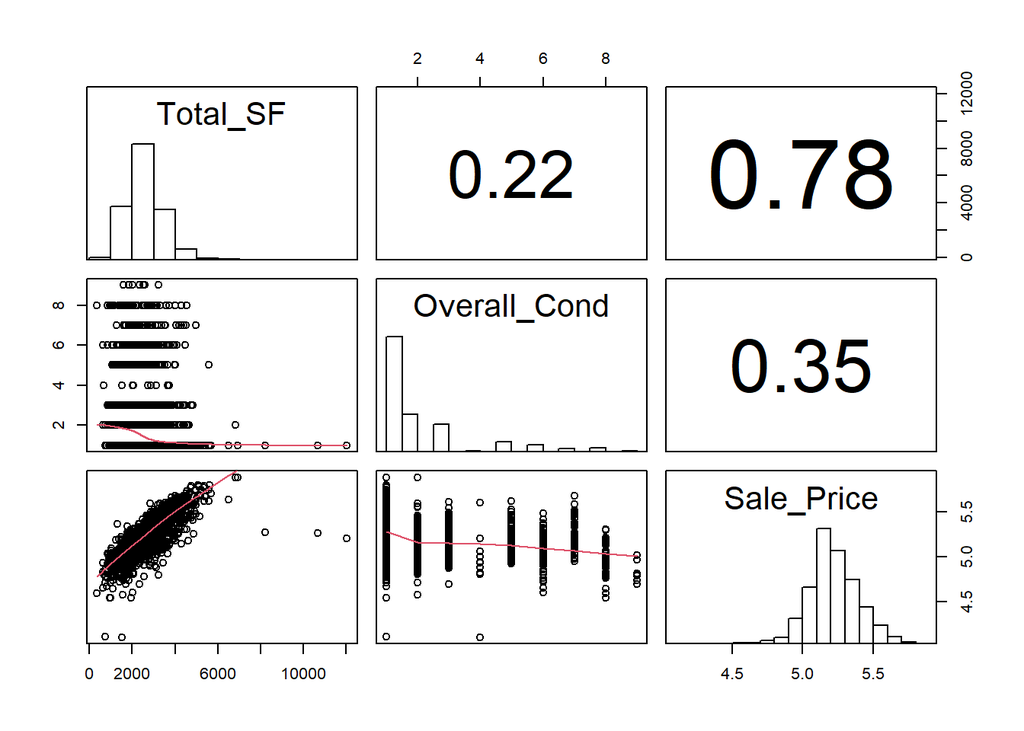

   ```r
   #-----Preprocessing-----
   data %<>%
     mutate(Overall_Cond = as_factor(Overall_Cond))

   #-----Enhancements for the pair plot function-----

   panel.cor <- function(x,y, digits=2, prefix="", cex.cor){
     usr <- par("usr")
     on.exit(par(usr))
     par(usr = c(0,1,0,1))
     r <- abs(cor(x,y,use="complete.obs"))
     txt <- format(c(r,0.123456789), digits = digits)[1]
     txt <- paste0(prefix, txt,sep="")
     if(missing(cex.cor)) cex.cor <- 0.8/strwidth(txt)
     text(0.5, 0.5, txt, cex = cex.cor * (1 + r) / 2)
   }

   panel.hist <- function(x, ...){
     usr <- par("usr")
     on.exit(par(usr))
     par(usr = c(usr[1:2],0,1.5))
     h <- hist(x, plot = FALSE)
     breaks <- h$breaks
     nB <- length(breaks)
     y <- h$counts
     y <- y/max(y)
     rect(breaks[-nB], 0, breaks[-1], y, col="white",...)
   }

   panel.lm <- function(x,y,col = par("col"), bg = NA, pch = par("pch"),
                        cex = 1, col.smooth = "steelblue",...){
     points(x,y,pch=pch, col=col, bg=bg, cex=cex)
     abline(stats::lm(x ~ y), col = "steelblue", ...)
   }

   #-----Pair Plotting/Grammar of Graphics Facets-----
   data %$%
     pairs( ~ Total_SF + Overall_Cond + Sale_Price,
            upper.panel= panel.cor,
            diag.panel=panel.hist,
            lower.panel=panel.smooth)
   ```

4. Perform data budgeting with **rsample**. For starters, use the classical cross-validation approach 80:20. Generate training and testing datasets. Inspect Q-Q plots.

   **Answer:** A key condition for linear regression fitting is that the dependent variable comes from the normal distribution. This can be checked with Q-Q plots and as we can see, there are no major deviations from the expected distribution.

   In essence, Q-Q plots take your data, sort it in ascending order, and then plot them versus quantiles calculated from a theoretical distribution. The number of quantiles is selected to match the size of your sample data.

   ```r
   ames_split <- initial_split(data, prop = 0.80, strata = Sale_Price)
   ames_train <- training(ames_split)
   ames_test  <-  testing(ames_split)
   ```

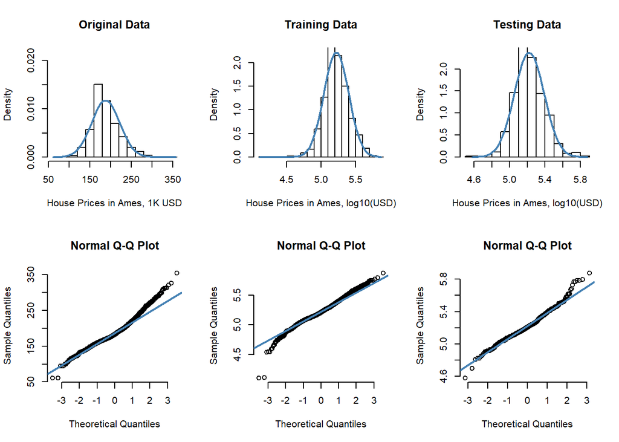

5. (**optional for DSP fellows**) Perform k-fold (sometimes called v-fold) cross-validation with 10 folds and use newly generated folds for model fitting.
6. Fit a simple regression model onto your training data.

   ```r
   lm_model <- linear_reg() %>% set_engine("lm")
   lm_train <- lm_model %>% fit(Sale_Price ~ Total_SF + Overall_Cond, data = ames_train) # Fit a linear model using training data
   lm_test <- lm_model %>% fit(Sale_Price ~ Total_SF + Overall_Cond, data = ames_test) # Fit a linear model using testing data
   ```

   Inspect residual plots, Q-Q plots and identify outliers and high-leverage points. List the concrete observations that are identified as either outliers and high-leverage points. Think about how do they impact your model. If needed, update your training/testing data and re-run linear regression fitting.

   On the plots below, the `autoplot()` function identifies deviated observations by their IDs, which are the values from the first column. If you decide to remove them from further analyses, just use the negative selection on the initial data and rerun the `initial_split()` `training()` and `testing()` functions.

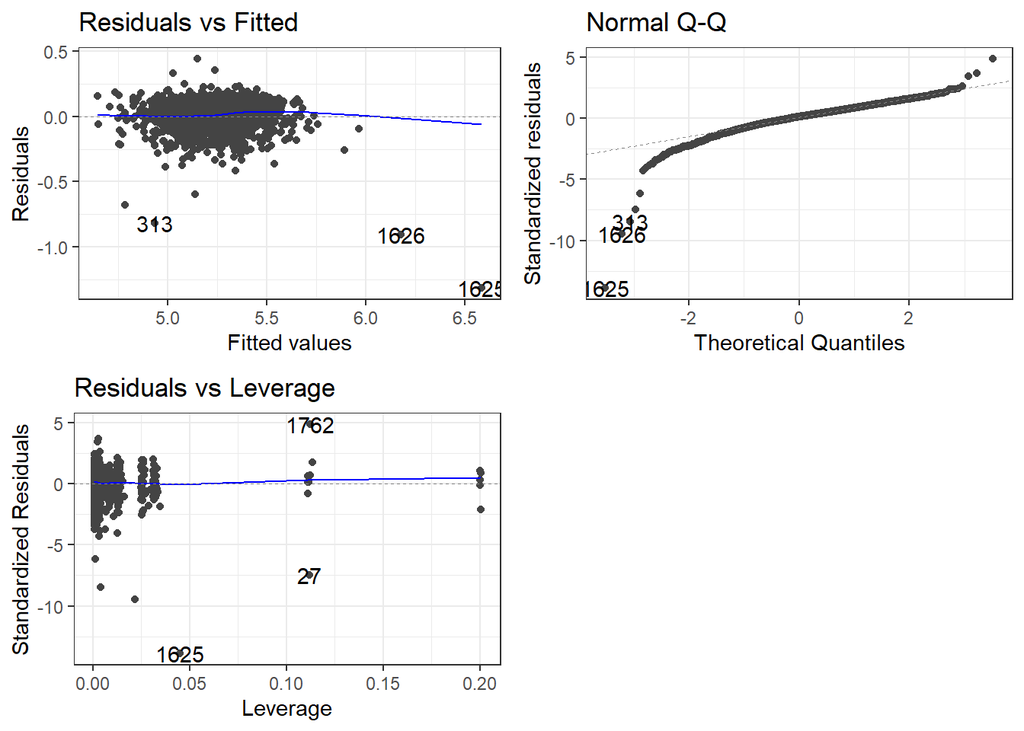

   ```r
   library(ggfortify)
   autoplot(lm_train$fit, which = c(1,2,5)) + theme_bw() # Note that syntax! Autoplot is built on ggplot2.
   ```

   ```r
   #You can also try:
   #par(mfrow = c(2,3)) ; plot(lm_train$fit, which = c(1,2,3,4,5,6))
   ```

7. Retrieve model coefficients from training and testing data. Combine both tables into a single table that conforms to the tidy data principles.

   ```r
   train <- tidy(lm_train) # Extracting model coefficients from the training set.
   test <- tidy(lm_test) # Extracting model coefficients from the test set.

   test %<>% mutate(type = "test")
   train %<>% mutate(type = "train")

   rbind(test, train) %>%
     arrange(term) %>%
     select(term, type, everything())
   ```

   ```
   ## # A tibble: 20 × 6
   ##    term                      type   estimate  std.error statistic  p.value
   ##    <chr>                     <chr>     <dbl>      <dbl>     <dbl>    <dbl>
   ##  1 (Intercept)               test   4.91     0.0159      308.     0
   ##  2 (Intercept)               train  4.81     0.00772     623.     0
   ##  3 Overall_CondAbove_Average test  -0.0572   0.0116       -4.95   9.99e- 7
   ##  4 Overall_CondAbove_Average train -0.0447   0.00560      -7.97   2.41e-15
   ##  5 Overall_CondBelow_Average test  -0.134    0.0247       -5.44   7.72e- 8
   ##  6 Overall_CondBelow_Average train -0.159    0.0111      -14.3    2.23e-44
   ##  7 Overall_CondExcellent     test  -0.000945 0.0361       -0.0262 9.79e- 1
   ##  8 Overall_CondExcellent     train  0.0137   0.0173        0.792  4.28e- 1
   ##  9 Overall_CondFair          test  -0.236    0.0342       -6.92   1.21e-11
   ## 10 Overall_CondFair          train -0.217    0.0157      -13.8    5.62e-42
   ## 11 Overall_CondGood          test  -0.0359   0.0132       -2.72   6.73e- 3
   ## 12 Overall_CondGood          train -0.0244   0.00633      -3.85   1.19e- 4
   ## 13 Overall_CondPoor          test  -0.349    0.107        -3.28   1.11e- 3
   ## 14 Overall_CondPoor          train -0.278    0.0324       -8.56   2.07e-17
   ## 15 Overall_CondVery_Good     test  -0.0160   0.0242       -0.659  5.10e- 1
   ## 16 Overall_CondVery_Good     train -0.0180   0.00925      -1.95   5.17e- 2
   ## 17 Overall_CondVery_Poor     test  -0.371    0.0755       -4.91   1.18e- 6
   ## 18 Overall_CondVery_Poor     train -0.367    0.0435       -8.44   5.38e-17
   ## 19 Total_SF                  test   0.000128 0.00000519   24.7    1.40e-92
   ## 20 Total_SF                  train  0.000166 0.00000259   64.0    0
   ```

8. Interpret model coefficients. How does the property’s condition impact its sale price? Always use the full sentence to describe what is actually happening. Saying that intercept is … and slope equals to … is not enough and will be rewarded by 0 at the test.

   **Answer:** Regression model shows that house prices in Ames depend on their living area (**Total_SF**), with further increase modulated by the house condition. The dependency between the condition and the overall price is probably not linear - perhaps logarithmic; the better the house condition is, the higher price addition. Be aware that to interpret the prices correctly, one has to unlog them first.

   The intercept is not really interpretable because all houses have non-zero living area. The slope tells you how much the price increases for every square feet the living area is enlarged. Given everything equal, for every square feet of living space increase there is increase of 0.000166$ (+/- 1.00000259) in price. These are log-ed values because the model was fit with log-transformed prices so be careful what you interpret.
9. Interpret the differences of model coefficients between training and testing data. Are these two analyses comparable? Is your training model stable? Which of the metrics would you pick to support your conclusions?

   **Answer:** Model stability is best interpreted with k-fold cross validation. Since not all of you have done it, let’s stick to standard errors for each coefficient that you get with base R. The log-ed standard error of Total_SF in training model is 0.00000259, which equates to 1.000003, when unlog-ed. This figure then compares to the testing error of 0.00000519 and 1.000005, respectively, which is comparably little.
10. (**optional**) Research how to plot regression lines from training and testing experiments onto all data using either base R plotting system of the ggplot2 library. Research how to color-code training and testing data on the same plot.

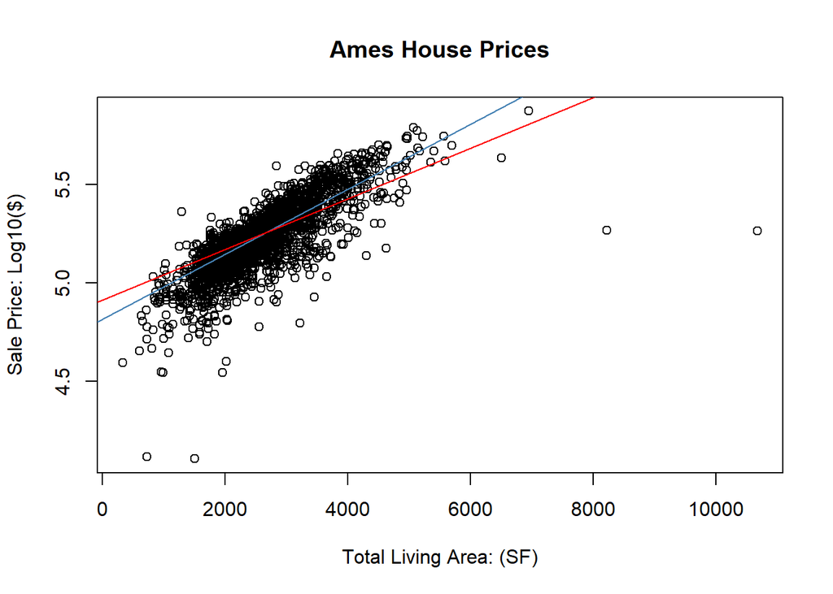

    ```r
    plot(ames_train$Total_SF, ames_train$Sale_Price,
         ylab = "Sale Price: Log10($)",
         xlab = "Total Living Area: (SF)",
         main = "Ames House Prices")
    abline(coef(lm_train$fit)[1:2] , col = "steelblue")
    abline(coef(lm_test$fit)[1:2] , col = "red")
    ```

11. (**optional**) Replace `stats::lm()` function with alternative fitting functions from either Keras or Stan packages. Did far more robust fitting brought any improvements?

### References

[^1]: De Cock, D. 2011. “Ames, Iowa: Alternative to the Boston Housing Data as an End of Semester Regression Project.” Journal of Statistics Education 19 (3). https://github.com/topepo/AmesHousing/blob/master/R/make_ames.R
[^2]: Friedman, J, T Hastie, and R Tibshirani. 2010. “Regularization Paths for Generalized Linear Models via Coordinate Descent.” Journal of Statistical Software 33 (1): 1.